# Dangerous ground: Thirteen-month-old infants are sensitive to peril in other people’s actions

Shari Liu

April 2, 2021

## Reliability + Distribution Info

# Figures

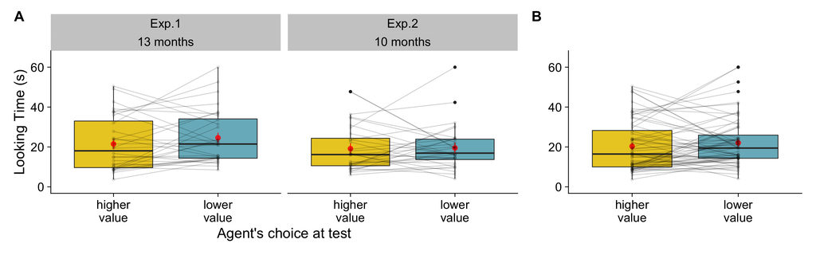

```
## [1] "shallow" "deep"
```

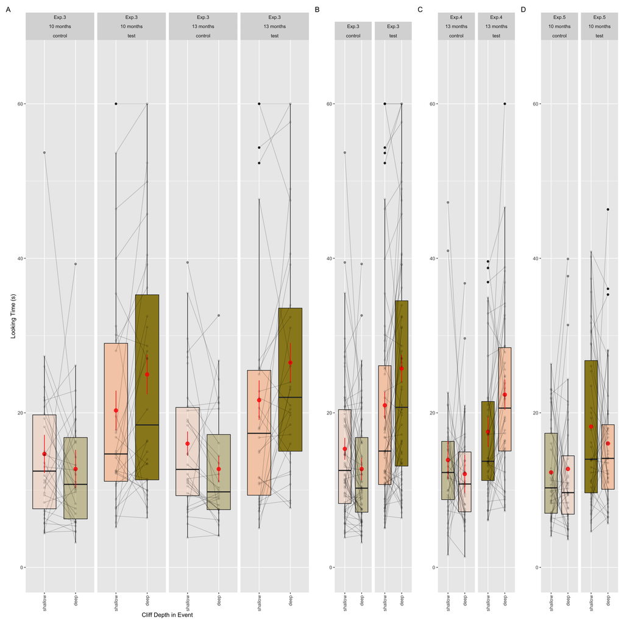

# Experiment 1: Inferring value from risk (13-month-old infants)

## Methods

### Participants

Our final sample of participants included N=32 13-month-old infants (M=12.887 months, range=12.567-13.467, 17 female). Seven infants were excluded and replaced due to fussiness (3 infants) or inattentiveness during test trials (4 infants). All data were collected at the Harvard Lab for Developmental Studies with procedures approved by the Committee on the Protection of Human Subjects. The methods, sample size, hypotheses, and analyses were pre-registered at https://osf.io/bs3e7/. We chose to study 13-month-old infants in Experiment 1 because younger infants were not available at the time the study began, and because 13-month-old infants have more experience with standing, walking, and falling: experiences that may be important for the development of these abilities (Kretch & Adolph, 2013).

### Data Coding and Analysis Strategy.

All experimenters and coders were naive to the nature and the order of the test events and were unable to see what the babies saw during the experiment (they relied on trial-neutral sound cues to start each trial). To check for exclusions and coding errors, all test trial data were re-coded in Datavyu and excluded as necessary: If an infant looked away from a test event without ever having seen the agent jump, or if the trial ended too early or late, that trial was marked and excluded from subsequent analysis (15 out of 384 total test trials). We used these offline coded looking times for our final analyses. To assess the reliability of the data, 50% of test trials from the experiment (192 out of 384 trials) were re-coded Datavyu by an additional researcher who was naive to test event order. Reliability was high, ICC=0.969, 95% CI [0.948, 0.982]. All decisions to include or exclude trials or participants from our analysis were made by researchers who were blind to the events seen by infants.

Infant looking times are often log-normally distributed (Csibra, Hernik, Mascaro, Tatone, & Lengyel, 2016), including in this dataset (log-likelihood of data for Experiments 1-4 under normal distribution = -2049.259, under lognormal distribution = -1925.384), so our pre-registered dependent measure was the average looking time towards the higher- or lower-danger choice at test in log seconds, and the values of unstandardized B coefficients and 95% confidence intervals are reported in this unit. Nevertheless, we include summary statistics and plots of untransformed looking times for interpretability. We analyzed all looking times using mixed effects models (Bates, Mächler, Bolker, & Walker, 2015) implemented in R. All analyses including repeated measures included a random intercept for participant identity. Analyses conducted over multiple experiments included a random intercept for experiment, except in one case where including this intercept lead to issues with convergence. For every model, we checked for influential participants using Cook’s Distance (Nieuwenhuis, te Grotenhuis, & Pelzer, 2012) and excluded any participants who exceeded the standard 4/n threshold, where n is the number of participants. The number of participants that met this criterion is listed in every model result.

## Results

### Pre-registered results.

We compared infants’ looking times when the agent approached the target for which it performed the more dangerous action (Higher Value) to the looking times when the agent approached the other target (Lower Value). Thirteen-month-old infants looked longer when the agent chose the target achieved through the lower-danger action (Mlower=24.601s (SE 6.963), Mhigher=21.483s (SE 6.963), 95% confidence interval (CI) over difference in log seconds [0.019,0.405], ß=0.349, B=0.212, SE=0.097, p=0.037, two-tailed excluding one influential participant). This looking preference is consistent with the interpretation that infants expected the agent to choose the target for which it had undertaken a more dangerous action and looked longer when this expected outcome did not occur.

# Experiment 2: Inferring value from risk (10-month-old infants)

#### Experiments 1 and 2: Inferring value from risk (10 and 13-month-old infants)

#### Comparing Exp 2 and LUTS Exp 3

## Methods

### Participants

Our final sample of participants included N=32 10-month-old infants (M=10.133 months, range=9.6-10.633, 15 female). We chose the sample size of this experiment based on a power analysis over the results from Experiment 1. An additional 6 infants participated but were excluded from and replaced in the final sample due to fussiness (2 infants), inattentiveness during test trials (1 infants), online coding error (2 infants), and interference from caregivers (1 infant). The design, sample size, hypotheses, and analyses of this experiment were pre-registered and open access at https://osf.io/uh8ns/.

### Materials, Procedure, Data Coding, Analysis.

The materials, procedures, coding, and analyses of Experiment 2 were identical to those of Experiment 1. Fourteen out of 384 test trials were marked and excluded from further analysis because of inattentiveness or coding error. To assess the reliability of the data, 50% of test trials from the experiment (192 test trials) were re-coded Datavyu by an additional researcher who was naive to test event order. Reliability was high, ICC=0.995, 95% CI [0.991, 0.997].

## Results

### Exploratory results.

#### Comparing Experiments 1 and 2.

To test whether 10- and 13-month-old infants performed differently, we compared the data from Experiments 1 and 2. Ten- and 13-month-old infants did not significantly differ in their looking preferences, [-0.111,0.29], ß=0.213, B=0.122, SE=0.144, p=0.398, two-tailed. Pooling results from Experiments 1 and 2, infants looked longer overall when the agent chose the goal that was achieved by the less dangerous action (Mlower=22.057s (SD=7.204), Mhigher=20.315s (SD=7.204), [0.01,0.293], ß=0.265, B=0.152, SE=0.072, p=0.019, one-tailed, excluding one influential participant).

# Experiment 3: Minimizing Risk (10mo infants)

# Experiment 3: Minimizing risk (13-month-old infants)

# Exp 3: Age groups together

## Methods

### Participants

Our final sample of participants included N=30 10-month-old infants (M=9.951 months, range=8.967-10.467, 17 female) and N=30 13-month-old infants (M=12.893 months, range=12.533-13.5, 12 female). We chose this sample size using a power analysis from a pilot study (effect size ß=0.323), as well as estimates of effect sizes of studies with similar displays and design (Liu & Spelke, 2017; Liu et al., 2017). Eight infants were excluded and replaced in the final sample due to fussiness (3 infants), inattentiveness during test trials (3 infants), or interference from caregivers (2 infants). The methods, sample size, hypotheses, and analyses of this experiment were pre-registered and open access at https://osf.io/kx928/.

## Results

### Comparing test events to control events

To test whether this looking preference reflected the relative danger of the different jumps, or other perceptual features of the shallow and deep trenches, we compared infants’ looking times during the control events, where their attention was drawn to each trench using an attention-getting star that was placed in the path of the agent’s subsequent actions. We found that infants showed a preference for the shallower trench in this context (Mdeep=12.734s (SD=5.595), Mshallow=15.345s (SD=5.504), [0.02,0.299], ß=0.277, B=0.159, SE=0.071, p=0.028, two-tailed, excluding 2 influential participants). Infants’ looking preferences between the control events and the test events significantly differed from each other ([-0.689,-0.136], ß=-0.616, B=-0.413, SE=0.141, p=0.004, two-tailed). Thus, infants’ expectations at test cannot be due to an intrinsic preference for events occurring over deeper to those over shallower trenches.

### Exploring age differences

#### Results in 13-month-old infants

Thirteen-month-old infants looked longer at test when the agent, at test, chose the deeper trench over the shallower trench (Mdeep=26.504s (SD=6.839), Mshallow=21.642s (SD=6.839), [-0.43,-0.033], ß=-0.356, B=-0.232, SE=0.1, p=0.014, one-tailed, excluding one influential participant. During control events, 13-month-old infants preferred to look at the shallow trench (Mdeep=12.728s (SD=4.343), Mshallow=16.015s (SD=4.207), [0.075,0.314], ß=0.339, B=0.193, SE=0.06, p=0.003, two-tailed, excluding 2 influential participants). Their looking preferences significantly differed across the two conditions, [-0.883,-0.114], ß=-0.751, B=-0.498, SE=0.197, p=0.013, two-tailed, two-tailed.

#### Results in 10-month-old infants

Ten-month-old looked longer at test when the agent chose the deeper the shallower trench (Mdeep=24.972s (SD=6.876), Mshallow=20.31s (SD=6.876), [-0.472,-0.047], ß=-0.386, B=-0.26, SE=0.107, p=0.011, one-tailed, excluding one influential participant. During control events, 10-month-old infants displayed no strong looking preference (Mdeep=12.739s (SD=6.627), Mshallow=14.675s (SD=6.627), [-0.174,0.301], ß=0.109, B=0.064, SE=0.119, p=0.598, two-tailed, excluding 1 influential participant). In contrast to the data from the 13-month-old infants, however, these two patterns of looking preference did not differ from each other, [-0.728,0.073], ß=-0.483, B=-0.327, SE=0.205, p=0.115, two-tailed.

#### Comparing 10-month-old and 13-month-old infants

The two groups of infants did not differ in their looking preferences between the two test events ([-0.327,0.275], ß=-0.04, B=-0.026, SE=0.154, p=0.865, two-tailed, excluding one influential participant), or between the two control events ([-0.194,0.363], ß=0.146, B=0.084, SE=0.142, p=0.559, two-tailed, excluding 2 influential participants). Infants of the two ages also did not show different looking preferences between the control and test events ([-0.724,0.381], ß=-0.255, B=-0.171, SE=0.285, p=0.549, two-tailed).

# Experiment 4: Replication of Experiment 3 (13-month-old infants)

# Data reliability and coding

To assess the reliability of the data, 50% of test trials from the experiment (252 of 504 total test trials) were re-coded Datavyu by an additional researcher who was naive to test event order. Reliability was high, ICC=0.955, 95% CI [0.931, 0.971].

## Pre-registered Analysis: Long looking to perilous action, different from control actions

### Participants

Our final sample of participants included N=42 13-month-old infants (M=13.954 months, range=12.286-15.67, 24 female).

### Comparing test events to control events

To test whether this looking preference reflected the relative danger of the different jumps, or other perceptual features of the shallow and deep trenches, we compared infants’ looking times during the control events, where their attention was drawn to each trench using an attention-getting star that was placed in the path of the agent’s subsequent actions. We found that infants showed a numerical but non-significant preference for the shallower trench in this context (Mdeep=12.087s (SD=7.176), Mshallow=13.9s (SD=7.176), [-0.071,0.416], ß=0.339, B=0.172, SE=0.124, p=0.171, two-tailed, excluding 2 influential participants). Infants’ looking preferences between the control events and the test events significantly differed from each other ([0.113,0.724], ß=0.752, B=0.419, SE=0.157, p=0.009, two-tailed).

# Experiment 5: Replication of Experiment 3 (10-month-old infants)

### Participants

Our final sample of participants included N=40 10-month-old infants (M=10.241 months, range=9.53-11.06, 20 female).

### Comparing test events to control events

# Supplemental Online Materials

## Including influential observations (reviewer suggestion)

Below, we report the results from all of our pre-registered analyses including all observations, rather than excluding influential observations.

### Experiment 1

Thirteen-month-old infants looked longer when the agent chose the target achieved through the lower-danger action Thirteen-month-old infants looked longer when the agent chose the target achieved through the lower-danger action (Mlower=24.601s, Mhigher=21.483s, 95% confidence interval (CI) over difference in log seconds [0.019,0.405], ß=0.349, B=0.212, SE=0.097, p=0.037, two-tailed). This looking preference is consistent with the interpretation that infants expected the agent to choose the target for which it had undertaken a more dangerous action and looked longer when this expected outcome did not occur.

### Experiment 2

Ten-month-old infants did not show a statistically significant looking preference between the test events, (Mlower=19.513s, Mhigher=19.148s, [-0.182,0.267], ß=0.077, B=0.043, SE=0.113, p=0.354, one-tailed, mixed effect model with fixed effect of test event and random intercept for participant identity).

### Experiment 3

#### Collapsing across age groups

Across both age groups, infants looked longer at test when the agent chose to jump the deeper trench than when the agent chose to jump the shallower trench (Mdeep=25.738s, Mshallow=20.976s, [-0.403,-0.085], ß=-0.365, B=-0.244, SE=0.08, p=0.002, one-tailed).

#### 13-month-olds

Thirteen-month-old infants looked longer at test when the agent, at test, chose the deeper trench over the shallower trench (Mdeep=26.504s, Mshallow=21.642s, [-0.506,-0.066], ß=-0.432, B=-0.286, SE=0.11, p=0.007, one-tailed, excluding one influential participant. During control events, 13-month-old infants preferred to look at the shallow trench (Mdeep=12.728s, Mshallow=16.015s, [0.02,0.374], ß=0.336, B=0.195, SE=0.089, p=0.036, two-tailed). Their looking preferences significantly differed across the two conditions, [-0.883,-0.114], ß=-0.751, B=-0.498, SE=0.197, p=0.013, two-tailed).

### Experiment 4

Thirteen-month-old infants looked longer at test when the agent chose to jump the deeper trench than when the agent chose to jump the shallower trench (Mdeep=22.355s, Mshallow=17.547s, [0.087,0.409], ß=0.47, B=0.248, SE=0.081, p=0.002, one-tailed).

## Order effects in Experiments 1 and 2 (reviewer suggestion)

### Experiment 1

### Experiment 2

Infants’ looking preferences at test did not vary depending on which sequence of events (low to high danger vs high to low danger) they were randomly assigned to watch in the first familiarization trial (Experiment 1: [-0.221,0.543], ß=0.266, B=0.161, SE=0.195, p=0.416, two-tailed; Experiment 2: [-0.368,0.528], ß=0.144, B=0.08, SE=0.229, p=0.73, two-tailed). All infants saw 3 familiarization trials in each order.

## Power analysis over experiment 1

## Power analysis over experiment 3

## Generate Data for Reliability